# Gustavo Diaz – crim_gov_apsa23

## Criminal Governance in Contexts of High State Presence and Low Violence

**Lucía Tiscornia**  
University College Dublin  
lucia.tiscornia@ucd.ie

**Ines Fynn**  
Universidad Católica del Uruguay ines.fynn@ucu.edu.uy

**Verónica Pérez Bentancur**  
Universidad de la República veronica.perez@cienciassociales.edu.uy

**Gustavo Diaz**  
McMaster University  
diazg2@mcmaster.ca

Slides and paper: [talks.gustavodiaz.org](https://talks.gustavodiaz.org/)

## Motivation

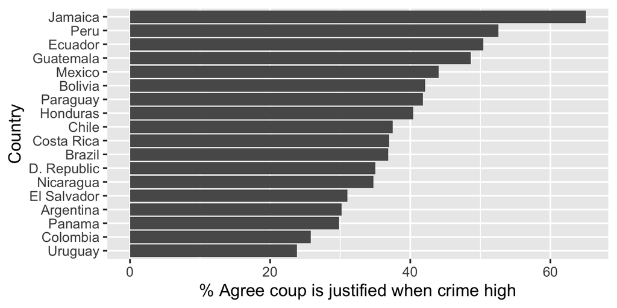

**Source:** LAPOP 2018

## Criminal governance

See [Arias (2017)](https://doi.org/10.1017/9781316650073), [Lessing (2021)](https://doi.org/10.1017/S1537592720001243), [Trejo and Ley (2021)](https://doi.org/10.1017/9781108894807)

## Criminal governance

Informal tools

See [Arias (2017)](https://doi.org/10.1017/9781316650073), [Lessing (2021)](https://doi.org/10.1017/S1537592720001243), [Trejo and Ley (2021)](https://doi.org/10.1017/9781108894807)

## Criminal governance

Informal tools to **control community behaviors**

See [Arias (2017)](https://doi.org/10.1017/9781316650073), [Lessing (2021)](https://doi.org/10.1017/S1537592720001243), [Trejo and Ley (2021)](https://doi.org/10.1017/9781108894807)

## Criminal governance

Informal tools to **control community behaviors** that involve **political, economic, or social aspects**

See [Arias (2017)](https://doi.org/10.1017/9781316650073), [Lessing (2021)](https://doi.org/10.1017/S1537592720001243), [Trejo and Ley (2021)](https://doi.org/10.1017/9781108894807)

## Criminal governance

Informal tools to **control community behaviors** that involve **political, economic, or social aspects** with the **goal of profiting from illicit markets**.

See [Arias (2017)](https://doi.org/10.1017/9781316650073), [Lessing (2021)](https://doi.org/10.1017/S1537592720001243), [Trejo and Ley (2021)](https://doi.org/10.1017/9781108894807)

## What we know so far

- Mix of violent and nonviolent strategies
- Emergence depends on criminal control and competition
- Where the state is absent
- But also alongside the state

Mostly from high violence, low state presence countries

## Questions

**Why** do we observe *criminal governance* mechanisms in contexts of **low violence** and **high state presence**?

**How** does *criminal governance* operate in these contexts?

## A theory of criminal governance under low violence and high state presence

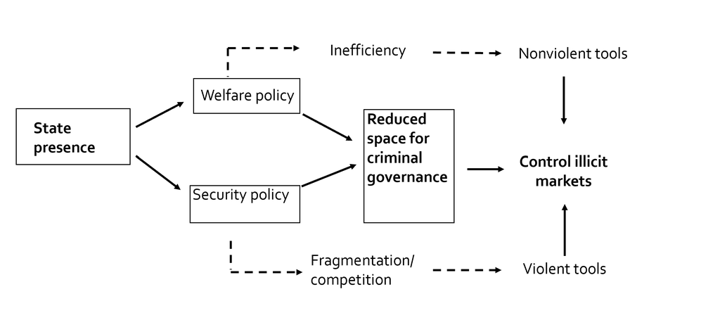

## Research Design

### Case selection: Montevideo, Uruguay

- Low violence and crime
- Extensive social protection
- **Crucial least likely case**

## Research Design

### Qualitative fieldwork (2021-2022)

- 76 in depth interviews
- Review of press and documents (2012-2022)
- **Criminal governance is a sensitive topic**

## Survey: Direct question

**During the last six months, in your neighborhood, have you seen criminal organizations…**

#### Violent

- Threaten neighbors
- Evict neighbors

#### Nonviolent

- Make donations to neighbors
- Offer jobs to neighbors

## Survey: NSUM questions

**How many X do you know,**

## Survey: NSUM questions

**How many X do you know, who also know you,**

## Survey: NSUM questions

**How many X do you know, who also know you, with whom you have interacted in the last year**

## Survey: NSUM questions

**How many X do you know, who also know you, with whom you have interacted in the last year in person, by phone, or any other channel?**

From *Las Piedras*  
Male 25-29  
Police officers  
University students  
Had a kid last year  
Passed away last year  
Married last year  
Female 45-49

Public employees  
Welfare card holders  
Registered with party  
With kids in public school  
Did not vote in last election  
Currently in jail  
Recently unemployed  
*[CRIMINAL GOVERNANCE TOOL]*

## Survey: Results

[figure not shown]

Vertical lines are 95% CI, horizontal ticks are 84% CI

## Survey: Results

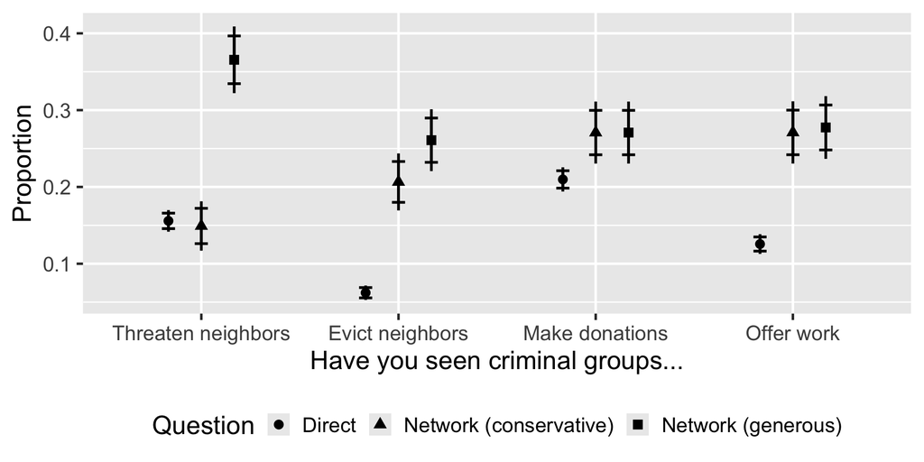

Vertical lines are 95% CI, horizontal ticks are 84% CI

## Interviews: Limited to economic mechanisms

*Politics for them does not exist, they are in the business [of selling drugs]. Politics is the business of other people, they are interested in having economic means quickly, but politics is not their strong suit*

*They are not well-organized enough to be involved in other things*

## Conclusion

- Criminal governance can persist under low crime, high state presence
- But no attempt at social/political control

### Implications

- Current explanations may be biased towards high violence cases
- Rethinking theoretical scope conditions

**Learn more:** [talks.gustavodiaz.org](https://talks.gustavodiaz.org/)